# Understanding Dimensional Modeling

Bernard Ade

Dimensional modeling is a design practice that organizes data in a manner that makes it easy to ask questions about your business from data stored in a database. Dimensional modeling should be important to any business or organization who wishes to turn data into knowledge. This post is aimed at startups and small to medium enterprises who still grapple with organizing data and making the best use of it for decision-making. In this digital age of information, the role and function of data has been redefined by technology and culture. Technologies that use to be out of reach are now inexpensive and accessible. To gain a competitive edge, even small to medium enterprises can pursue strategies to extract knowledge from data to drive productivity and growth.

### What is Dimensional Modeling?

As mentioned earlier the goal of the dimensional modeling is to organize data in a manner that allows you to query and analyze your data for useful insights. While there are several approaches to modeling enterprise data, dimensional modeling is considered to be best practice in the field because of its simplicity and effectiveness. The goal of utilizing dimensional modeling is to satisfy the following interrogatives: Who, What, When, Where, How and Why. You want the ability to ask questions that gives you multiple perspectives about your business. Ralph Kimball is the architect of this design principle and the author of the book The Data Warehouse Toolkit which is a comprehensive guide to dimensional modeling.

Usually, building an industry standard data warehouse for analytic purposes involves a lot of time, money and technical resource however there are tools on the market that makes the process relatively easy to hack so you can take advantage of the benefits of dimensional modeling. These tools allow you to build a relational database similar to a SQL database without having to write code. Relational database structures data using tables which are collection of data records such as sales, customers, products, salesperson etc.

Here is an example of an image representation of a dimensional model schema.

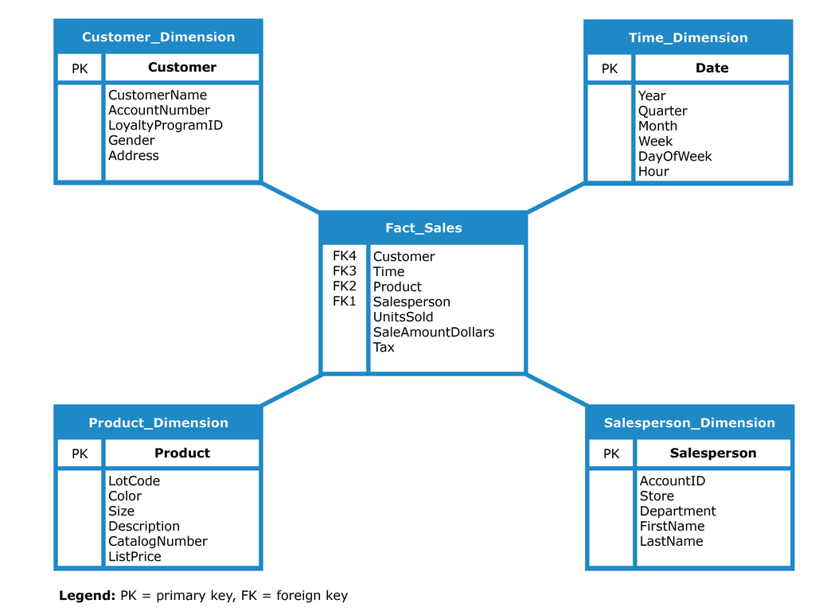

The key takeaway on how dimensional modeling works is understanding FACTS and DIMENSIONS. Consider questions such as:

*What is percent total each year by market segments?*

*What is the total sales by top 10 states?*

*What are the gross margins by product by region?*

Each of these questions boils down to facts and dimensions. **Facts** records the measurements from business processes. Examples of facts are **numeric** data such as sales, shipment, gross margin, discount, return rate etc.

**Dimensions** records the context of measurements from business processes. Examples of dimensions include date, region, salesperson, customer, product etc.

A dimensional model organizes these facts and dimensions for storage in a database.

Suppose you have succeeded in implementing a dimensional model and you now have a bunch of data to query. Now we can ask all sorts of questions and create visualizations and reports to gain multiple perspectives of facts by dimensions.

Using some R code, here are examples of scripts querying data and displaying charts for business insights.

```r
library(tidyverse)
library(highcharter)
library(lubridate)
superstore = read.csv('superstore.csv')
superstore =
    superstore %>%
      mutate(Order.Date = mdy(Order.Date))%>%
      mutate(Ship.Date = mdy(Ship.Date))%>%
      arrange(Order.Date)
```

```r
superstore
```

| Row.ID | Order.ID | Order.Date | Ship.Date | Ship.Mode | Customer.ID | Customer.Name | Segment | Country | City | State | Postal.Code | Region | Product.ID | Category | Sub.Category | Product.Name | Sales | Quantity | Discount | Profit |
| --- | --- | --- | --- | --- | --- | --- | --- | --- | --- | --- | --- | --- | --- | --- | --- | --- | --- | --- | --- | --- |
| 7981 | CA-2011-103800 | 2011-01-04 | 2011-01-08 | Standard Class | DP-13000 | Darren Powers | Consumer | United States | Houston | Texas | 77095 | Central | OFF-PA-10000174 | Office Supplies | Paper | Message Book, Wirebound, Four 5 1/2" X 4" Forms/Pg., 200 Dupl. Sets/Book | 16.4480 | 2 | 0.20 | 5.5512 |
| 740 | CA-2011-112326 | 2011-01-05 | 2011-01-09 | Standard Class | PO-19195 | Phillina Ober | Home Office | United States | Naperville | Illinois | 60540 | Central | OFF-LA-10003223 | Office Supplies | Labels | Avery 508 | 11.7840 | 3 | 0.20 | 4.2717 |
| 741 | CA-2011-112326 | 2011-01-05 | 2011-01-09 | Standard Class | PO-19195 | Phillina Ober | Home Office | United States | Naperville | Illinois | 60540 | Central | OFF-ST-10002743 | Office Supplies | Storage | SAFCO Boltless Steel Shelving | 272.7360 | 3 | 0.20 | -64.7748 |
| 742 | CA-2011-112326 | 2011-01-05 | 2011-01-09 | Standard Class | PO-19195 | Phillina Ober | Home Office | United States | Naperville | Illinois | 60540 | Central | OFF-BI-10004094 | Office Supplies | Binders | GBC Standard Plastic Binding Systems Combs | 3.5400 | 2 | 0.80 | -5.4870 |
| 1760 | CA-2011-141817 | 2011-01-06 | 2011-01-13 | Standard Class | MB-18085 | Mick Brown | Consumer | United States | Philadelphia | Pennsylvania | 19143 | East | OFF-AR-10003478 | Office Supplies | Art | Avery Hi-Liter EverBold Pen Style Fluorescent Highlighters, 4/Pack | 19.5360 | 3 | 0.20 | 4.8840 |
| 5328 | CA-2011-130813 | 2011-01-07 | 2011-01-09 | Second Class | LS-17230 | Lycoris Saunders | Consumer | United States | Los Angeles | California | 90049 | West | OFF-PA-10002005 | Office Supplies | Paper | Xerox 225 | 19.4400 | 3 | 0.00 | 9.3312 |
| 7181 | CA-2011-106054 | 2011-01-07 | 2011-01-08 | First Class | JO-15145 | Jack O'Briant | Corporate | United States | Athens | Georgia | 30605 | South | OFF-AR-10002399 | Office Supplies | Art | Dixon Prang Watercolor Pencils, 10-Color Set with Brush | 12.7800 | 3 | 0.00 | 5.2398 |
| 7475 | CA-2011-167199 | 2011-01-07 | 2011-01-11 | Standard Class | ME-17320 | Maria Etezadi | Home Office | United States | Henderson | Kentucky | 42420 | South | FUR-CH-10004063 | Furniture | Chairs | Global Deluxe High-Back Manager's Chair | 2573.8200 | 9 | 0.00 | 746.4078 |
| 7476 | CA-2011-167199 | 2011-01-07 | 2011-01-11 | Standard Class | ME-17320 | Maria Etezadi | Home Office | United States | Henderson | Kentucky | 42420 | South | OFF-BI-10004632 | Office Supplies | Binders | Ibico Hi-Tech Manual Binding System | 609.9800 | 2 | 0.00 | 274.4910 |
| 7477 | CA-2011-167199 | 2011-01-07 | 2011-01-11 | Standard Class | ME-17320 | Maria Etezadi | Home Office | United States | Henderson | Kentucky | 42420 | South | OFF-AR-10001662 | Office Supplies | Art | Rogers Handheld Barrel Pencil Sharpener | 5.4800 | 2 | 0.00 | 1.4796 |

[output cut: 990 more lines]

### What is percent total each year by market segment?

```r
percent_total =
  superstore %>%
  mutate(year = year(Order.Date)) %>%
  group_by(Segment, year)%>%
  summarise(sum_sales  = sum(Sales)) %>%
  mutate(percent_of_total = round(sum_sales/sum(sum_sales)*100, 1))
percent_total
```

| Segment | year | sum_sales | percent_of_total |
| --- | --- | --- | --- |
| Consumer | 2011 | 266096.81 | 22.9 |
| Consumer | 2012 | 266535.93 | 22.9 |
| Consumer | 2013 | 296295.54 | 25.5 |
| Consumer | 2014 | 332473.06 | 28.6 |
| Corporate | 2011 | 128434.87 | 18.2 |
| Corporate | 2012 | 128757.31 | 18.2 |
| Corporate | 2013 | 206942.95 | 29.3 |
| Corporate | 2014 | 242011.23 | 34.3 |
| Home Office | 2011 | 89715.81 | 20.9 |
| Home Office | 2012 | 75239.27 | 17.5 |

[output cut: 2 more lines]

```r
hchart(percent_total, "line", color = c("#B71C1C", "#348ABD", "#9B59B6"), hcaes(x = year, y = percent_of_total, group = Segment )) %>%
  hc_title(text = "Percent total each year by market segment", margin = 20, align = "left") %>%
  hc_credits(enabled = TRUE, text = "Tableau superstore dataset", style = list(fontSize = "10px"))
```

[interactive chart not shown]

### What is the total sales by top 10 states?

```r
top10_states =
superstore %>%
  group_by(State)%>%
  summarise(Sales_Total = sum(Sales)) %>%
  top_n(10, Sales_Total)%>%
  arrange(desc(Sales_Total))
top10_states
```

| State | Sales_Total |
| --- | --- |
| California | 457687.63 |
| New York | 310876.27 |
| Texas | 170188.05 |
| Washington | 138641.27 |
| Pennsylvania | 116511.91 |
| Florida | 89473.71 |
| Illinois | 80166.10 |
| Ohio | 78258.14 |
| Michigan | 76269.61 |
| Virginia | 70636.72 |

```r
highchart() %>%
  hc_add_series(data = top10_states, type = "bar", color = "#1F77B4",
                name = "Total", hcaes(x = State, y = Sales_Total)) %>%
  hc_title(text = "Top 10 sales by States", margin = 20, align = "left") %>%
  hc_xAxis(categories = as.list(superstore$State)) %>%
  hc_credits(enabled = TRUE, text = "Tableau superstore dataset", style = list(fontSize = "10px"))
```

[interactive chart not shown]

While this is a simplified introduction to dimensional modeling I hope you’re inspired to look into implementing this wonderful concept at your organization.

Here are a couple of apps that functions like a database and makes it relatively easy to organize data without coding.

[Airtable](https://airtable.com/)

[Fieldbooks](https://fieldbook.com/)

[Metabase](http://www.metabase.com/)

###### Ralph Kimball, Margy Ross. (2013). The Data Warehouse Toolkit. 3rd Edition. Wiley

###### Source for image (http://www.softwareadvice.com/resources/olap-data-warehouse-alternatives/)